# Finding Information

Information & Interaction Design

Mick McQuaid

mcq@utexas.edu

University of Texas at Austin

17 Aug 2026

# Week ELEVEN

# Finding Information

*In the future, attention will be our most precious resource.*

## Search engines

- Revelation of personal information when you search
- What do you think? Should you be compensated?
- Read Page et al. (1999) and Wikipedia on PageRank

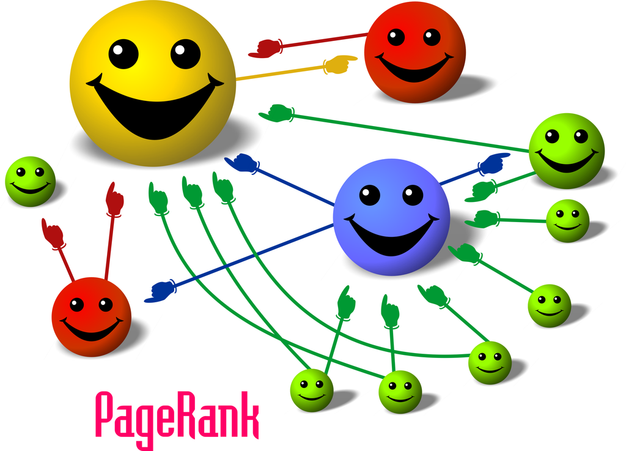

[figure not shown]

## Limits of search engines

- Search by example
- Search for things for which you have no name
- Link rot

## Conversational interfaces

- Initial hype
- The long game
- First mover advantage vs market dominance
- Corrosive influence of OpenAI on StackOverflow

## Information credibility

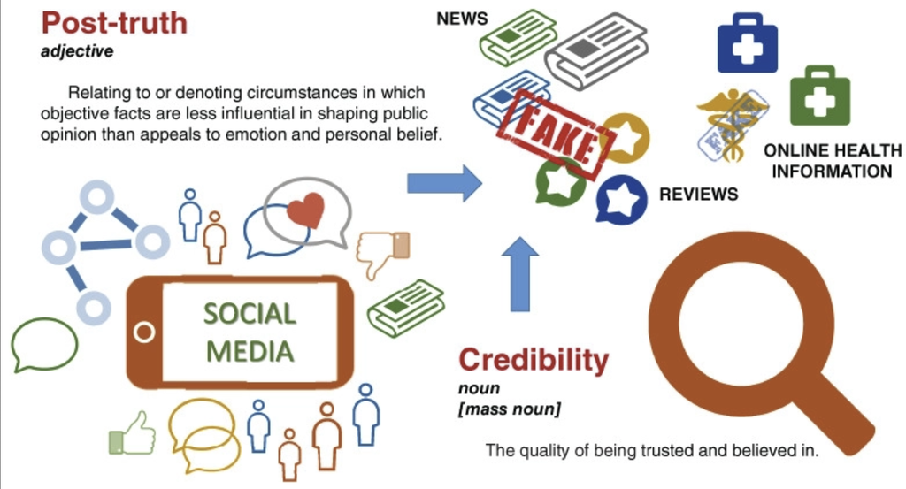

## Information credibility concepts

1. Technical knowledge, skill or expertise
2. Consistency of actions, values, meathods, measures, principles, expectations, and outcomes (definition of journalistic integrity from Wikipedia)
3. Objectivity
4. Pecuniary Interest
5. Agreement with ideas and values held by the recipient
6. Community membership
7. Precision (variance)
8. Accuracy (bias)
9. Falsifiability (using scientific method)

## Getting help

[figure not shown]

## Exercise: comparing help for two browsers

Form an ad hoc group. Identify two browsers, such as Chrome, Firefox, Safari, or others. (Firefox and Chrome are easiest to study because they are heavily programmable and offer a lot of customization possibilities that may require help, such as skinning, global or domain-specific CSS add-ons, and other plugins.) Contrast the Youtube videos and user communities offering help for the two browsers.

Compare the health of the browsers in terms of instructional videos. Identify features of videos that alter your perception of the video. This could include things like the presence of ads before the videos (what does that tell you?), logos on videos, tenor of discussions, propensity of video maker to reply in discussions, number and range of videos by maker, presence of features like channels to organize videos, and more.

Compare the communities supporting the two browsers and identify differences in focus, emphasis, direction, and mission. Be specific about numbers of posts, recency of posts, topics of posts, and other salient features in community forums. What is the attitude of moderators? Do the moderators express an attitude? How transparent are moderation features?

# Navigating Information

Knowing what’s going on is a lifelong occupation. You can not expect to use knowledge you acquired years ago without at least some adjustment today. I wanted to devote a talk to information architecture but the received wisdom on information architecture is outdated. The most frequently cited book on information architecture, Peter Morville’s book of 2006, seems in 2015 like a prehistoric fossil. Just now, while checking its date of publication I discovered that it is still a bestseller and that Morville released a new edition in August 2015. Nevertheless, the oft-cited 2006 edition contains the extract in the following frame.

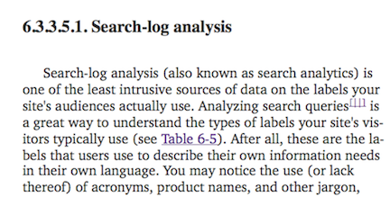

A sub-sub-sub-sub-section

## Analytics

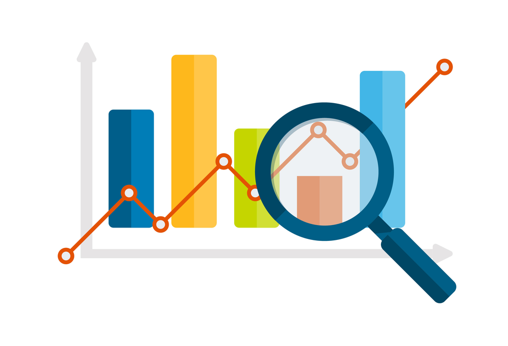

Pictures accompanying analytics articles always feature a magnifying glass

## Google analytics

[figure not shown]

The logo for Google Analytics in focus

## Gaming the system

## Metadata

data about data

## Information Architecture

The Information Architecture Institute offers the following definition of information architecture in their pdf, referenced in the Wikipedia article on Information Architecture.

We define information architecture as

- The structural design of shared information environments.
- The art and science of organizing and labeling web sites, intranets, online communities, and software to support usability and findability.
- An emerging community of practice focused on bringing principles of design and architecture to the digital landscape.

## Information architecture tools

- conceptual
- commercial

[figure not shown]

baby busy box

## Information hiding

[figure not shown]

## Information comparison

[figure not shown]

## Organizational information maturity

*Da real woild jist ain’t like dat!*

—Someone in an information-immature  
organization

# END

# References

Page, Lawrence, Sergey Brin, Rajeev Motwani, and Terry Winograd. 1999. *The PageRank Citation Ranking: Bringing Order to the Web.* No. 422. Stanford InfoLab.

Pirolli, Peter, and Stuart Card. 1999. “Information Foraging.” *Psychological Review* (Washington, DC) 106 (4): 643–75.

Proença, Diogo, and José Borbinha. 2016. “Maturity Models for Information Systems - a State of the Art.” *Procedia Computer Science* 100: 1042–49. https://doi.org/10.1016/j.procs.2016.09.279.

Rieh, Soo Young, and Brian Hilligoss. 2008. “College Students’ Credibility Judgments in the Information-Seeking Process.” In *Digital Media, Youth, and Credibility*, edited by Miriam J. Metzger and Andrew J. Flanagin. The MIT Press.

Spruit, Marco, and Katharina Pietzka. 2015. “MD3M: The Master Data Management Maturity Model.” *Computers in Human Behavior* 51 (October): 1068–76. https://doi.org/10.1016/j.chb.2014.09.030.

Viviani, Marco, and Gabriella Pasi. 2017. “Credibility in Social Media: Opinions, News, and Health Information—a Survey.” *WIREs Data Mining and Knowledge Discovery* 7 (5): e1209. https://doi.org/https://doi.org/10.1002/widm.1209.

# Colophon

This slideshow was produced using `quarto`

Fonts are *Fira Sans*, *Fira Sans Light*, and *Victor Mono Nerd Font*

Math is set in *Fira Math* via *MathJax 4*